# chapter3

Joonas Luukkonen

14 11 2019

## Logistic Regression

**2.**

The data approach student achievement in secondary education of two Portuguese schools. There are 382 observations of 35 variables (+ techical variable x, which appeared for some reason after reading data into r.) in the dataset after structuration. In addition to factor, integer and numerical variables there is a logical variable as well, the one which was created for the purpose of logistic regression.

```r
setwd("~/IODS-project/data")
read.csv("alc.csv")
```

[output not shown]

[output cut: 1517 more lines]

```r
alc <- read.csv("alc.csv")
colnames(alc)
```

```
##  [1] "X"          "school"     "sex"        "age"        "address"
##  [6] "famsize"    "Pstatus"    "Medu"       "Fedu"       "Mjob"
## [11] "Fjob"       "reason"     "nursery"    "internet"   "guardian"
## [16] "traveltime" "studytime"  "failures"   "schoolsup"  "famsup"
## [21] "paid"       "activities" "higher"     "romantic"   "famrel"
## [26] "freetime"   "goout"      "Dalc"       "Walc"       "health"
## [31] "absences"   "G1"         "G2"         "G3"         "alc_use"
## [36] "high_use"
```

```r
str(alc)
```

```
## 'data.frame':    382 obs. of  36 variables:
##  $ X         : int  1 2 3 4 5 6 7 8 9 10 ...
##  $ school    : Factor w/ 2 levels "GP","MS": 1 1 1 1 1 1 1 1 1 1 ...
##  $ sex       : Factor w/ 2 levels "F","M": 1 1 1 1 1 2 2 1 2 2 ...
##  $ age       : int  18 17 15 15 16 16 16 17 15 15 ...
##  $ address   : Factor w/ 2 levels "R","U": 2 2 2 2 2 2 2 2 2 2 ...
##  $ famsize   : Factor w/ 2 levels "GT3","LE3": 1 1 2 1 1 2 2 1 2 1 ...
##  $ Pstatus   : Factor w/ 2 levels "A","T": 1 2 2 2 2 2 2 1 1 2 ...
##  $ Medu      : int  4 1 1 4 3 4 2 4 3 3 ...
##  $ Fedu      : int  4 1 1 2 3 3 2 4 2 4 ...
##  $ Mjob      : Factor w/ 5 levels "at_home","health",..: 1 1 1 2 3 4 3 3 4 3 ...
##  $ Fjob      : Factor w/ 5 levels "at_home","health",..: 5 3 3 4 3 3 3 5 3 3 ...
##  $ reason    : Factor w/ 4 levels "course","home",..: 1 1 3 2 2 4 2 2 2 2 ...
##  $ nursery   : Factor w/ 2 levels "no","yes": 2 1 2 2 2 2 2 2 2 2 ...
##  $ internet  : Factor w/ 2 levels "no","yes": 1 2 2 2 1 2 2 1 2 2 ...
```

[output cut: 22 more lines]

```r
dim(alc)
```

```
## [1] 382  36
```

```r
head(alc)
```

```
##   X school sex age address famsize Pstatus Medu Fedu     Mjob     Fjob
## 1 1     GP   F  18       U     GT3       A    4    4  at_home  teacher
## 2 2     GP   F  17       U     GT3       T    1    1  at_home    other
## 3 3     GP   F  15       U     LE3       T    1    1  at_home    other
## 4 4     GP   F  15       U     GT3       T    4    2   health services
## 5 5     GP   F  16       U     GT3       T    3    3    other    other
## 6 6     GP   M  16       U     LE3       T    4    3 services    other
##       reason nursery internet guardian traveltime studytime failures
## 1     course     yes       no   mother          2         2        0
## 2     course      no      yes   father          1         2        0
## 3      other     yes      yes   mother          1         2        2
## 4       home     yes      yes   mother          1         3        0
## 5       home     yes       no   father          1         2        0
## 6 reputation     yes      yes   mother          1         2        0
##   schoolsup famsup paid activities higher romantic famrel freetime goout
## 1       yes     no   no         no    yes       no      4        3     4
## 2        no    yes   no         no    yes       no      5        3     3
## 3       yes     no  yes         no    yes       no      4        3     2
## 4        no    yes  yes        yes    yes      yes      3        2     2
## 5        no    yes  yes         no    yes       no      4        3     2
## 6        no    yes  yes        yes    yes       no      5        4     2
##   Dalc Walc health absences G1 G2 G3 alc_use high_use
## 1    1    1      3        5  2  8  8     1.0    FALSE
## 2    1    1      3        3  7  8  8     1.0    FALSE
## 3    2    3      3        8 10 10 11     2.5     TRUE
## 4    1    1      5        1 14 14 14     1.0    FALSE
## 5    1    2      5        2  8 12 12     1.5    FALSE
## 6    1    2      5        8 14 14 14     1.5    FALSE
```

```r
library(ggplot2)
library(dplyr)
library(tidyr)
```

**3.**

I chose *absences*, *going out with friens (goout)*, *mother’s education* and *father’s job* for variables predicting student’s alcohol consumption. My hypothesis is, that the absences from school is the strongest predictor of alcohol consumption of the four chosen predictors. I also assume, that going out with friends have a clear connection with alcohol consumption: the more one goes out, the more one consumes alcohol, on average. Third hypothesis is, that family’s socio-economic position (mother’s education + father’s job) has an inverse connection to alcohol consumption of a child: the lower the family’s socio-economic position, the more there is certain type of risk behavior (alcohol consumption) even intergenerationally.

**4.**

For preliminary, graphical exploration of the hypothesis formulated, following box plot graphs are printed for integer variables *goout* and *absences*.

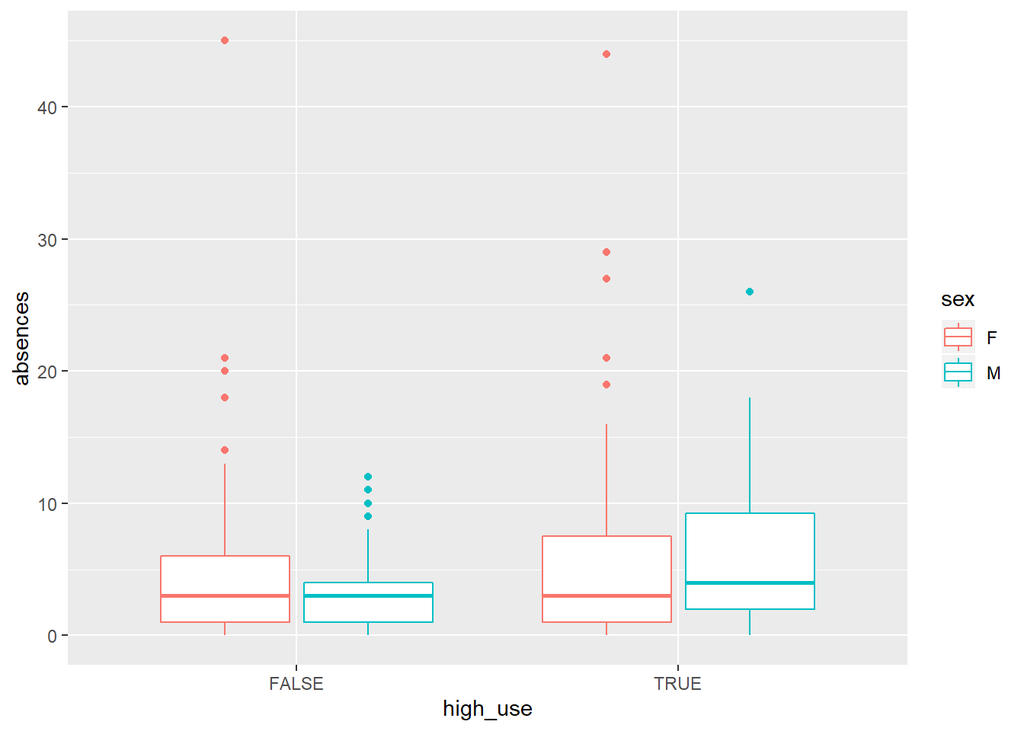

```r
g1 <- ggplot(alc, aes(x = high_use, y = absences, col = sex))
g2 <- ggplot(alc, aes(x = high_use, y = goout, col = sex))
g1 + geom_boxplot()
```

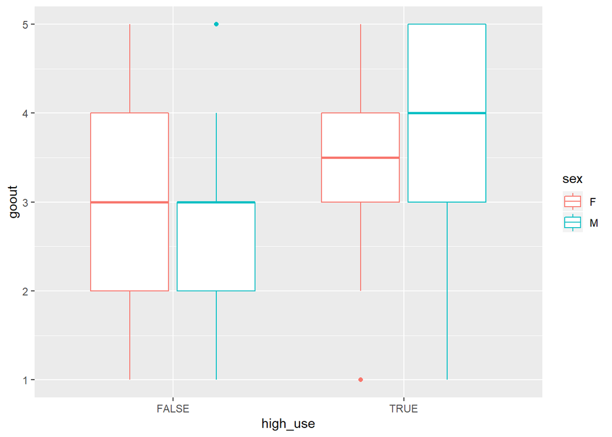

```r
g2 + geom_boxplot()
```

It seems, that there are some differences in absences between high_users and low_users of alcohol. The differences are more clear among men. Men whose alcohol consumption is high, have more absences from school in general. Also, high consuming men’s distribution of absences seems wider than those who do not consume as much and seems skewed as well. Between high and not-high consuming females there are not so clear difference in absences based on boxplot diagram. Some outliers can be detected among all four classes in question. Among females there seem to be more outliers, that drastically differ from main population in absences, than among men. Going out seems to have a clear connection with alcohol consumption. For both female and men a high consumption of alcohol indicates a higher outgoing rate.

For gategorial variables concerning family’s socio-economic position, boxplot diagrams are not reasonable solution. Therefore, pobability tables are printed for Medu and Fjob with following commands and results:

```r
attach(alc)
mytable0 <- table(high_use)
mytable0
```

```
## high_use
## FALSE  TRUE
##   268   114
```

```r
prop.table(mytable0)
```

```
## high_use
##     FALSE      TRUE
## 0.7015707 0.2984293
```

```r
mytable <- table(Fjob, high_use)
mytable
```

```
##           high_use
## Fjob       FALSE TRUE
##   at_home     14    2
##   health      13    4
##   other      149   62
##   services    67   40
##   teacher     25    6
```

```r
prop.table(mytable, 1)
```

```
##           high_use
## Fjob           FALSE      TRUE
##   at_home  0.8750000 0.1250000
##   health   0.7647059 0.2352941
##   other    0.7061611 0.2938389
##   services 0.6261682 0.3738318
##   teacher  0.8064516 0.1935484
```

```r
mytable2 <- table(Medu, high_use)
mytable2
```

```
##     high_use
## Medu FALSE TRUE
##    0     1    2
##    1    33   18
##    2    80   18
##    3    59   36
##    4    95   40
```

```r
prop.table(mytable2, 1)
```

```
##     high_use
## Medu     FALSE      TRUE
##    0 0.3333333 0.6666667
##    1 0.6470588 0.3529412
##    2 0.8163265 0.1836735
##    3 0.6210526 0.3789474
##    4 0.7037037 0.2962963
```

```r
chisq.test(mytable)
```

```
##
##  Pearson's Chi-squared test
##
## data:  mytable
## X-squared = 7.1778, df = 4, p-value = 0.1268
```

```r
chisq.test(mytable2)
```

```
##
##  Pearson's Chi-squared test
##
## data:  mytable2
## X-squared = 11.775, df = 4, p-value = 0.0191
```

In average, the probability of high alcohol consumption is ~ 30 %. From tables concerning father’s job, it can be seen, that especially students, whose father works at service sector, have a higher probability of high alcohol usage compared to students, whose fathers work in other sectors. Mother’s education does not have a straightforward relationship with students high alcohol consumption. Although students, whose mothers do not have any education, have clearly higher probability (66%) for high alcohol usage, it must be noticed, that there are only 3 students whose mother do not have any education in the data, which means that any conlcusions of those students cannot be drawn. Based on chi-square tests, father’s job doesn’t have statistically significant connection to student’s alcohol consumption, but mother’s education does have.

In contrast to my hypotheses, it seems that going out might be the strongest predictor of high alcohol consumption, rather than absences from school. Also, family’s socioeconomic position does have a connection, but the interpretation with these two variables in question (Medu, Fjob) is difficult due to shortages in sample size.

**5.**

Logistic regression is utilized to form a predictive model for alcohol consumption, using following commands:

```r
m <- glm(high_use ~ Fjob + Medu + goout + absences, data = alc, family = "binomial")
summary(m)
```

```
##
## Call:
## glm(formula = high_use ~ Fjob + Medu + goout + absences, family = "binomial",
##     data = alc)
##
## Deviance Residuals:
##     Min       1Q   Median       3Q      Max
## -1.8866  -0.7804  -0.5554   0.8854   2.4079
##
## Coefficients:
##              Estimate Std. Error z value Pr(>|z|)
## (Intercept)  -4.53829    0.92553  -4.903 9.42e-07 ***
## Fjobhealth    0.60259    0.99512   0.606 0.544818
## Fjobother     0.85834    0.79461   1.080 0.280050
## Fjobservices  1.33889    0.80861   1.656 0.097766 .
## Fjobteacher   0.30601    0.93443   0.327 0.743301
## Medu         -0.02015    0.12079  -0.167 0.867490
## goout         0.74436    0.11896   6.257 3.92e-10 ***
## absences      0.07683    0.02251   3.413 0.000643 ***
## ---
## Signif. codes:  0 '***' 0.001 '**' 0.01 '*' 0.05 '.' 0.1 ' ' 1
##
## (Dispersion parameter for binomial family taken to be 1)
##
##     Null deviance: 465.68  on 381  degrees of freedom
## Residual deviance: 395.11  on 374  degrees of freedom
## AIC: 411.11
##
## Number of Fisher Scoring iterations: 4
```

```r
OR <- coef(m) %>% exp
CI <- confint(m) %>% exp
cbind(OR, CI)
```

```
##                      OR       2.5 %      97.5 %
## (Intercept)  0.01069165 0.001312637  0.05555929
## Fjobhealth   1.82684300 0.274371446 15.92422759
## Fjobother    2.35924185 0.596708164 15.77444797
## Fjobservices 3.81479474 0.932973456 25.98660923
## Fjobteacher  1.35800019 0.239357299 10.89282334
## Medu         0.98004813 0.773500235  1.24334301
## goout        2.10508797 1.676682452  2.67561855
## absences     1.07986226 1.035215955  1.13186353
```

Logistic regression model confirms the interpretation presented above: going out is the srongest predictor for high alcohol consumption. One unit increase in going out means that the odds ratio for belonging to the group of high alcohol consuming students grows 2,1. This is not exactly the same as saying “probability increases two times”, although in reality it can be close to this kind of interpretation (relative risk vs. odds ratio, eg. https://journal.fi/janus/article/download/50456/15253, in Finnish, unfortunately). Absences from school is statistically significant predictor as well, but it’s effect seems modest. Partly this can be explained by the relatively large scale of the variable. If standardized, the effect would appear much stronger.

The model interprets mother’s education to be numerical due to variable’s numerical coding. In this case, this can be accepted, because mother’s education (based on crosstabs) didn’t have the kind of relationship with alcohol consumption, that would have had a straightforward theoretical interpretation. That is, there were a statistically significant variation with alcohol usage, but as the connection was not even close to linear, this was enough to question my hypothesis concerning especially mother’s low education.

Father’s job is considered as a factor variable in the model. Since the first class of the variable works as a reference group for others, it seems that students whose father works at a service sector, have a higher probability of high consumption of alcohol (OR = 3,81) compared to students whose father works / is at home (this category is not included visibly in the model). However, the value of the estimate is not statistically significant, so with this number of observations, this kind of interpretation cannot be made.

**6.**

Based on AIC criterion, a better fitting (simpler) model is formed by dropping statistically non-significant variables (Medu, Fjob) out of the model. Step by step it can be seen, that AIC has the lowest value with only two statistically significant predictors (goout and absences) in the model (AIC = 408,5), although, the differences are modest.

```r
m1 <- glm(high_use ~ Fjob + goout + absences, data = alc, family = "binomial")
summary(m1)
```

```
##
## Call:
## glm(formula = high_use ~ Fjob + goout + absences, family = "binomial",
##     data = alc)
##
## Deviance Residuals:
##     Min       1Q   Median       3Q      Max
## -1.8868  -0.7831  -0.5612   0.8959   2.4044
##
## Coefficients:
##              Estimate Std. Error z value Pr(>|z|)
## (Intercept)  -4.58738    0.87909  -5.218 1.81e-07 ***
## Fjobhealth    0.58795    0.99170   0.593 0.553270
## Fjobother     0.85735    0.79501   1.078 0.280846
## Fjobservices  1.33554    0.80874   1.651 0.098659 .
## Fjobteacher   0.28172    0.92327   0.305 0.760264
## goout         0.74360    0.11887   6.256 3.96e-10 ***
## absences      0.07654    0.02244   3.411 0.000648 ***
## ---
## Signif. codes:  0 '***' 0.001 '**' 0.01 '*' 0.05 '.' 0.1 ' ' 1
##
## (Dispersion parameter for binomial family taken to be 1)
##
##     Null deviance: 465.68  on 381  degrees of freedom
## Residual deviance: 395.14  on 375  degrees of freedom
## AIC: 409.14
##
## Number of Fisher Scoring iterations: 4
```

```r
OR <- coef(m1) %>% exp
CI <- confint(m1) %>% exp
cbind(OR, CI)
```

```
##                      OR       2.5 %      97.5 %
## (Intercept)  0.01017947 0.001343874  0.04796635
## Fjobhealth   1.80029096 0.272528679 15.61959813
## Fjobother    2.35691789 0.595702770 15.76861178
## Fjobservices 3.80205572 0.929991554 25.90839965
## Fjobteacher  1.32541059 0.239495282 10.46342160
## goout        2.10350198 1.675712336  2.67317870
## absences     1.07955007 1.035062573  1.13137478
```

```r
m2 <- glm(high_use ~ goout + absences, data = alc, family = "binomial")
summary(m2)
```

```
##
## Call:
## glm(formula = high_use ~ goout + absences, family = "binomial",
##     data = alc)
##
## Deviance Residuals:
##     Min       1Q   Median       3Q      Max
## -1.9111  -0.7480  -0.5173   0.9427   2.3741
##
## Coefficients:
##             Estimate Std. Error z value Pr(>|z|)
## (Intercept) -3.64647    0.43400  -8.402  < 2e-16 ***
## goout        0.73590    0.11715   6.282 3.35e-10 ***
## absences     0.07703    0.02209   3.487 0.000489 ***
## ---
## Signif. codes:  0 '***' 0.001 '**' 0.01 '*' 0.05 '.' 0.1 ' ' 1
##
## (Dispersion parameter for binomial family taken to be 1)
##
##     Null deviance: 465.68  on 381  degrees of freedom
## Residual deviance: 402.50  on 379  degrees of freedom
## AIC: 408.5
##
## Number of Fisher Scoring iterations: 4
```

```r
OR <- coef(m2) %>% exp
CI <- confint(m2) %>% exp
cbind(OR, CI)
```

```
##                   OR      2.5 %     97.5 %
## (Intercept) 0.026083 0.01076768 0.05922061
## goout       2.087359 1.66817170 2.64318173
## absences    1.080069 1.03581041 1.13071158
```

A “confusion matrix” shows, that a model does have power predicting observations right, but it must be noticed, that there exist misclassified observations as well.

Utilizing a loss function, the average number of correct (accuracy) and incorrect (penalty) predictions can be estimated. Based on the latter loss function, the average number of incorrect predictions is about 23,6 percentage.

```r
probabilities <- predict(m2, type = "response")
alc <- mutate(alc, probability = probabilities)
alc <- mutate(alc, prediction = probability > 0.5)
table(high_use = alc$high_use, prediction = alc$prediction)
```

```
##         prediction
## high_use FALSE TRUE
##    FALSE   245   23
##    TRUE     67   47
```

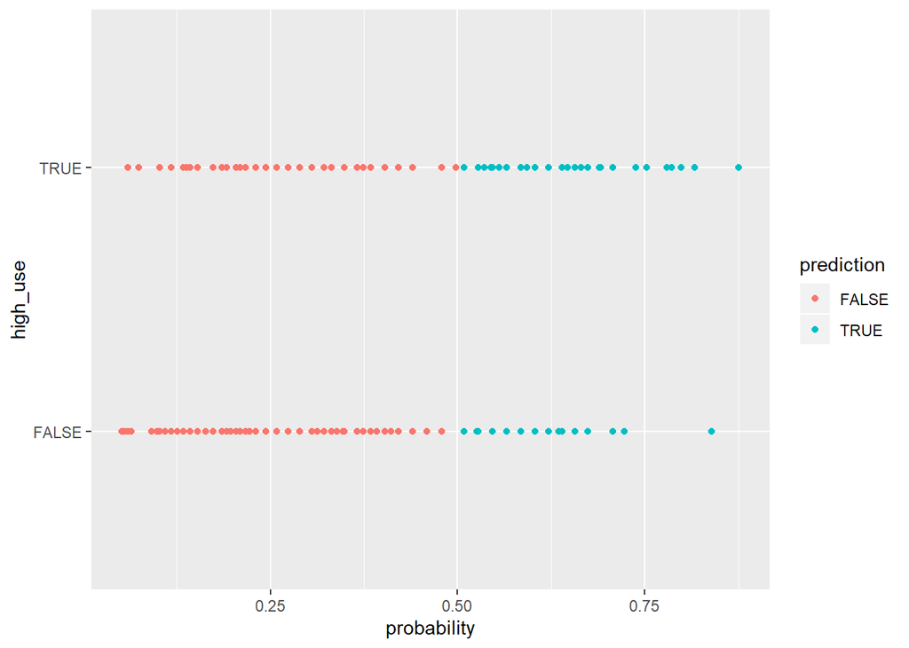

```r
g6 <- ggplot(alc, aes(x = probability, y = high_use, col = prediction))
g6 + geom_point()
```

```r
table(high_use = alc$high_use, prediction = alc$prediction) %>% prop.table %>% addmargins
```

```
##         prediction
## high_use      FALSE       TRUE        Sum
##    FALSE 0.64136126 0.06020942 0.70157068
##    TRUE  0.17539267 0.12303665 0.29842932
##    Sum   0.81675393 0.18324607 1.00000000
```

```r
loss_func <- function(class, prob) {
n_wrong <- abs(class - prob) > 0.5
mean(n_wrong)
}

loss_func(class = alc$high_use, prob = 1)
```

```
## [1] 0.7015707
```

```r
loss_func(class = alc$high_use, prob = 0)
```

```
## [1] 0.2984293
```

```r
loss_func(class = alc$high_use, prob = alc$probability)
```

```
## [1] 0.2356021
```

**7.**

Following commands are executed for 10-fold cross-validation of the model.

```r
library(boot)
cv <- cv.glm(data = alc, cost = loss_func, glmfit = m, K = 10)
cv$delta[1]
```

```
## [1] 0.2513089
```